# Udacity - Data Analyst Nano Degree Project 4: Exploring Red Wine Quality with R

Created by: Layne Newhouse

Resubmitted: November 15, 2016

This data set contains approximately 1,600 red wines with 11 variables regarding the chemical properties of the wine. At least 3 wine experts rated the quality of each wine, providing a rating between 0 (very bad) and 10 (very excellent).

In this project we wish to seek which chemical properties influence the quality of red wines.

## Uni/bivariate Plots Section

We will begin this exploration by outputting the size of the data set (‘objects’ x ‘variables’), an overview of each of the variable’s types, as well as summary statistics regarding each of the individual predictor variables in the data set.

```
## [1] 1599   13
```

```
## 'data.frame':    1599 obs. of  13 variables:
##  $ X                   : int  1 2 3 4 5 6 7 8 9 10 ...
##  $ fixed.acidity       : num  7.4 7.8 7.8 11.2 7.4 7.4 7.9 7.3 7.8 7.5 ...
##  $ volatile.acidity    : num  0.7 0.88 0.76 0.28 0.7 0.66 0.6 0.65 0.58 0.5 ...
##  $ citric.acid         : num  0 0 0.04 0.56 0 0 0.06 0 0.02 0.36 ...
##  $ residual.sugar      : num  1.9 2.6 2.3 1.9 1.9 1.8 1.6 1.2 2 6.1 ...
##  $ chlorides           : num  0.076 0.098 0.092 0.075 0.076 0.075 0.069 0.065 0.073 0.071 ...
##  $ free.sulfur.dioxide : num  11 25 15 17 11 13 15 15 9 17 ...
##  $ total.sulfur.dioxide: num  34 67 54 60 34 40 59 21 18 102 ...
##  $ density             : num  0.998 0.997 0.997 0.998 0.998 ...
##  $ pH                  : num  3.51 3.2 3.26 3.16 3.51 3.51 3.3 3.39 3.36 3.35 ...
##  $ sulphates           : num  0.56 0.68 0.65 0.58 0.56 0.56 0.46 0.47 0.57 0.8 ...
##  $ alcohol             : num  9.4 9.8 9.8 9.8 9.4 9.4 9.4 10 9.5 10.5 ...
##  $ quality             : int  5 5 5 6 5 5 5 7 7 5 ...
```

```
##        X          fixed.acidity   volatile.acidity  citric.acid
##  Min.   :   1.0   Min.   : 4.60   Min.   :0.1200   Min.   :0.000
##  1st Qu.: 400.5   1st Qu.: 7.10   1st Qu.:0.3900   1st Qu.:0.090
##  Median : 800.0   Median : 7.90   Median :0.5200   Median :0.260
##  Mean   : 800.0   Mean   : 8.32   Mean   :0.5278   Mean   :0.271
##  3rd Qu.:1199.5   3rd Qu.: 9.20   3rd Qu.:0.6400   3rd Qu.:0.420
##  Max.   :1599.0   Max.   :15.90   Max.   :1.5800   Max.   :1.000
##  residual.sugar     chlorides       free.sulfur.dioxide
##  Min.   : 0.900   Min.   :0.01200   Min.   : 1.00
##  1st Qu.: 1.900   1st Qu.:0.07000   1st Qu.: 7.00
##  Median : 2.200   Median :0.07900   Median :14.00
##  Mean   : 2.539   Mean   :0.08747   Mean   :15.87
##  3rd Qu.: 2.600   3rd Qu.:0.09000   3rd Qu.:21.00
##  Max.   :15.500   Max.   :0.61100   Max.   :72.00
##  total.sulfur.dioxide    density             pH          sulphates
##  Min.   :  6.00       Min.   :0.9901   Min.   :2.740   Min.   :0.3300
##  1st Qu.: 22.00       1st Qu.:0.9956   1st Qu.:3.210   1st Qu.:0.5500
##  Median : 38.00       Median :0.9968   Median :3.310   Median :0.6200
##  Mean   : 46.47       Mean   :0.9967   Mean   :3.311   Mean   :0.6581
##  3rd Qu.: 62.00       3rd Qu.:0.9978   3rd Qu.:3.400   3rd Qu.:0.7300
##  Max.   :289.00       Max.   :1.0037   Max.   :4.010   Max.   :2.0000
##     alcohol         quality
##  Min.   : 8.40   Min.   :3.000
##  1st Qu.: 9.50   1st Qu.:5.000
##  Median :10.20   Median :6.000
##  Mean   :10.42   Mean   :5.636
##  3rd Qu.:11.10   3rd Qu.:6.000
##  Max.   :14.90   Max.   :8.000
```

The bar graph below shows the quality of wine, given as an integer, as well how many bottles were given the respective ranking.

Due to the fact that this histogram is not completely normalized we should expect to see a predicting model that is biased towards the rankings 5 and 6. This is because the 5 and 6 quality rankings make up roughly 80% of all bottles of wine in the data set.

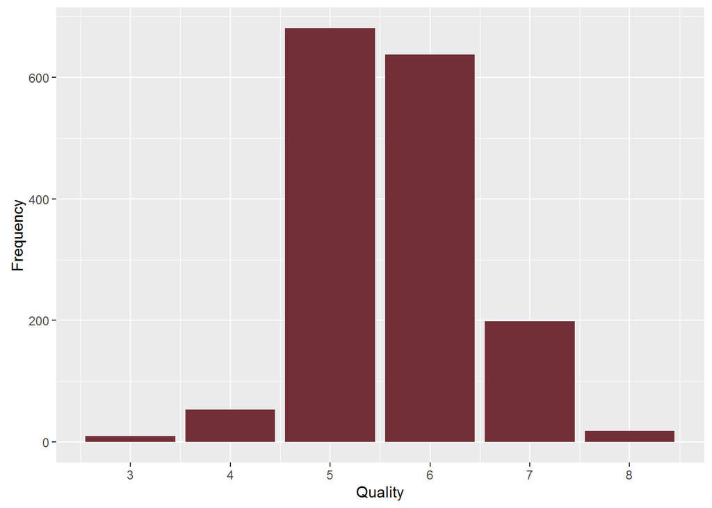

The section below includes individual analysis on each of the potential predicting variables for wine quality. Histograms have been created to understand the distribution of each of these variables and box plots were created to visualize statistical values for each variable as a function of quality. Two transformation were made on each variable in the form of ‘square root’ and ‘log base 10’ in order to try to achieve normality within the distributions as well as reduce the number of outliers within the respective box plots. A linear model was then created comparing these transformations to each other, as well as the un-transformed data, in attempt to decide which would be the best fit for our model. The lower the deviance, or residual sum of squares, the better fit the variable is to the linear model. In order to maintain conciseness throughout this project only one transformation and the original histogram will be shown below along with one box plot per variable.

The first variable that will be analyzed is Fixed Acidity (tartaric acid - g / dm^3).

Although the distribution became slightly more normalized through each transformation (square root and log base 10), the attempted transformations to this variable were not significant enough and did not decrease the linear model’s deviance. Therefore the unaltered data will be used.

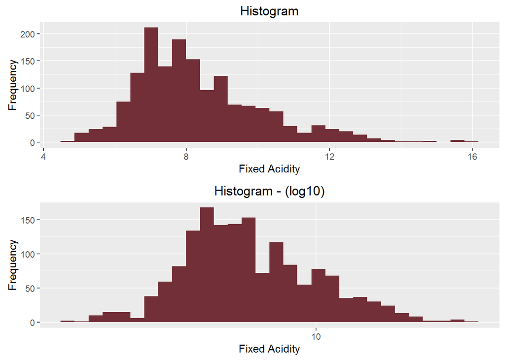

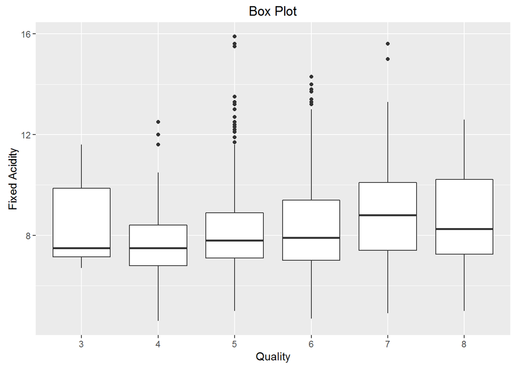

```
##
## Calls:
## m1: lm(formula = quality ~ fixed.acidity, data = redWine)
## m2: lm(formula = quality ~ I(sqrt(fixed.acidity)), data = redWine)
## m3: lm(formula = quality ~ I(log(fixed.acidity)), data = redWine)
##
## ===========================================================
##                              m1         m2         m3
## -----------------------------------------------------------
##   (Intercept)              5.157***   4.686***   4.665***
##                           (0.098)    (0.198)    (0.212)
##   fixed.acidity            0.058***
##                           (0.012)
##   I(sqrt(fixed.acidity))              0.331***
##                                      (0.069)
##   I(log(fixed.acidity))                          0.463***
##                                                 (0.101)
## -----------------------------------------------------------
##   R-squared                    0.0        0.0        0.0
##   adj. R-squared               0.0        0.0        0.0
##   sigma                        0.8        0.8        0.8
##   F                           25.0       23.3       21.1
##   p                            0.0        0.0        0.0
##   Log-likelihood           -1914.2    -1915.1    -1916.1
##   Deviance                  1026.1     1027.2     1028.6
##   AIC                       3834.5     3836.1     3838.3
##   BIC                       3850.6     3852.3     3854.4
##   N                         1599       1599       1599
## ===========================================================
```

Volatile Acidity (acetic acid - g / dm^3) has a distribution that is closest to normal after being transformed by the square root function. This along with having fewer outliers in the box plots as well as having the lowest deviance from the linear model makes this particular transformation valuable going forward. Since the units for this variable were g / dm^3 I was interested in seeing if the cubed root of the variable would yield a lower deviance. The results of this were that the square root transformation on Volatile Acidity was still the better transformation.

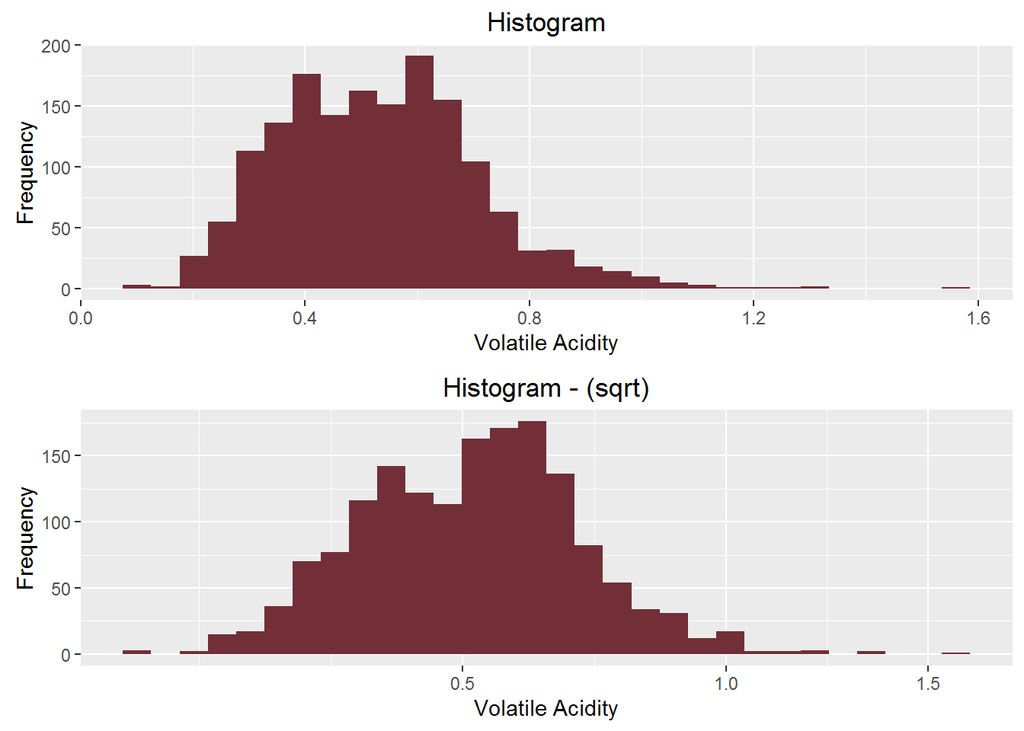

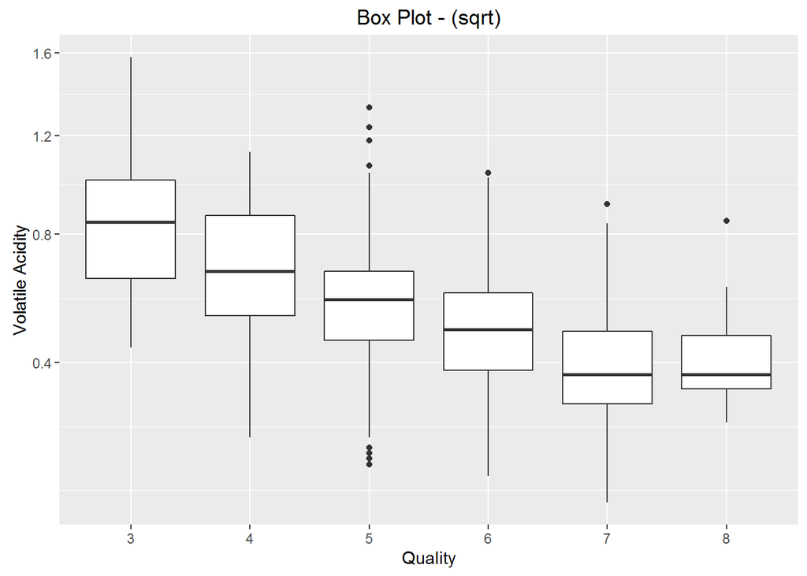

```
##
## Calls:
## m1: lm(formula = quality ~ volatile.acidity, data = redWine)
## m2: lm(formula = quality ~ I(sqrt(volatile.acidity)), data = redWine)
## m3: lm(formula = quality ~ I((volatile.acidity)^(1/3)), data = redWine)
## m4: lm(formula = quality ~ I(log(volatile.acidity)), data = redWine)
##
## ===========================================================================
##                                   m1         m2         m3         m4
## ---------------------------------------------------------------------------
##   (Intercept)                   6.566***   7.489***   8.392***   5.012***
##                                (0.058)    (0.110)    (0.162)    (0.041)
##   volatile.acidity             -1.761***
##                                (0.104)
##   I(sqrt(volatile.acidity))               -2.588***
##                                           (0.151)
##   I((volatile.acidity)^(1/3))                        -3.455***
##                                                      (0.202)
##   I(log(volatile.acidity))                                      -0.893***
##                                                                 (0.053)
## ---------------------------------------------------------------------------
##   R-squared                         0.2        0.2        0.2        0.2
##   adj. R-squared                    0.2        0.2        0.2        0.2
##   sigma                             0.7        0.7        0.7        0.7
##   F                               287.4      293.4      293.1      288.6
##   p                                 0.0        0.0        0.0        0.0
##   Log-likelihood                -1794.3    -1791.8    -1791.9    -1793.8
##   Deviance                        883.2      880.4      880.6      882.6
##   AIC                            3594.6     3589.6     3589.9     3593.6
##   BIC                            3610.8     3605.7     3606.0     3609.7
##   N                              1599       1599       1599       1599
## ===========================================================================
```

The log transformation of the following variable can not be done due to the ‘0’ values relating to Citric Acid (g / dm^3) content. The un-transformed version of this variable maintained the least amount of outliers while also having a lower deviance from the linear model when compared to the squared root transformation.

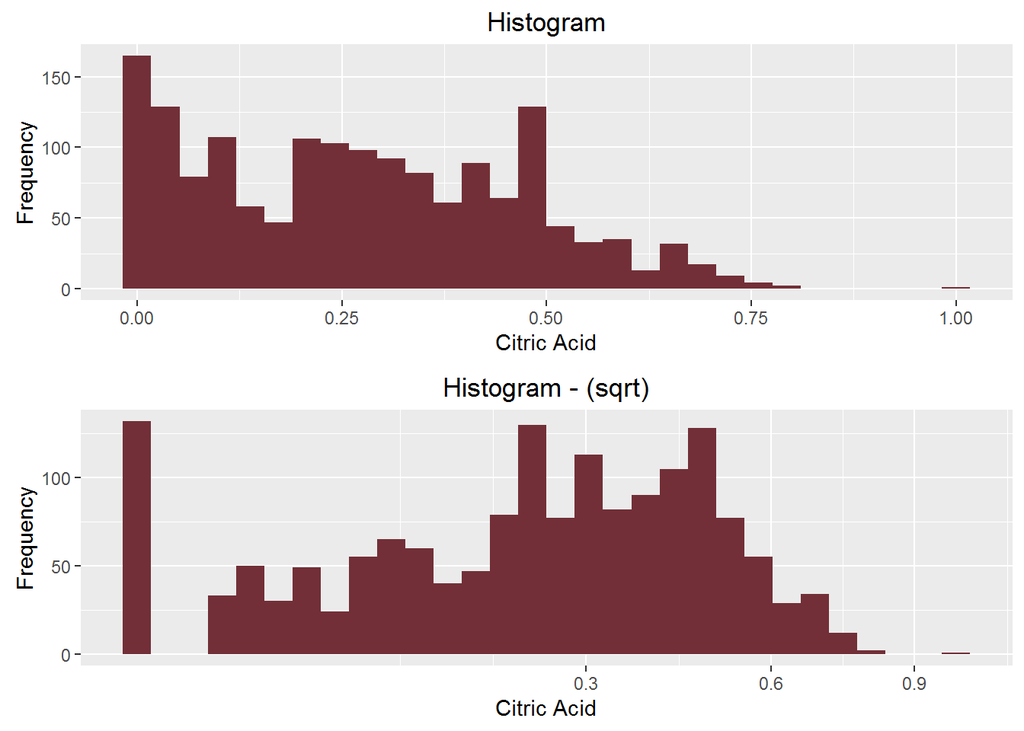

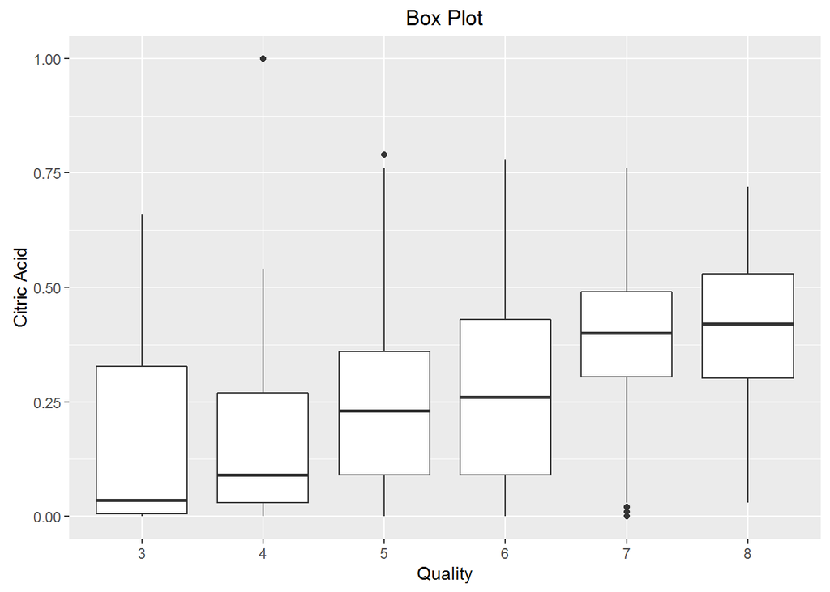

```
##
## Calls:
## m1: lm(formula = quality ~ citric.acid, data = redWine)
## m2: lm(formula = quality ~ I(sqrt(citric.acid)), data = redWine)
##
## ==============================================
##                            m1         m2
## ----------------------------------------------
##   (Intercept)            5.382***   5.298***
##                         (0.034)    (0.045)
##   citric.acid            0.938***
##                         (0.101)
##   I(sqrt(citric.acid))              0.724***
##                                    (0.086)
## ----------------------------------------------
##   R-squared                  0.1        0.0
##   adj. R-squared             0.1        0.0
##   sigma                      0.8        0.8
##   F                         86.3       71.3
##   p                          0.0        0.0
##   Log-likelihood         -1884.6    -1891.7
##   Deviance                 988.8      997.6
##   AIC                     3775.2     3789.5
##   BIC                     3791.3     3805.6
##   N                       1599       1599
## ==============================================
```

The log base 10 transformation of the Residual Sugar variable (g / dm^3) not only has the lowest deviance but also resembles a more normal distribution. Analysis of the linear regression table shows that regardless of the transformation, the standard errors of the linear regression estimate are far too large in comparison to the coefficients and thus are not statistically significant.

```
## $y
## [1] "Frequency"
##
## attr(,"class")
## [1] "labels"
```

```
## $y
## [1] "Frequency"
##
## attr(,"class")
## [1] "labels"
```

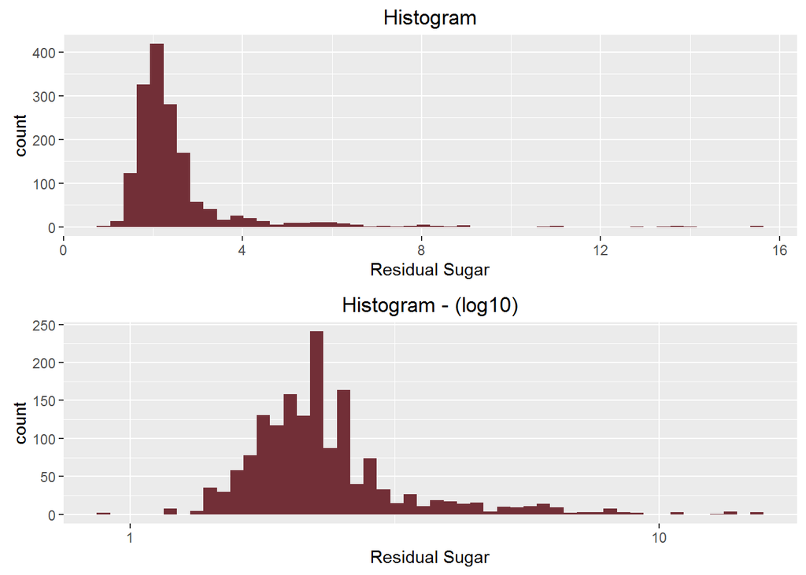

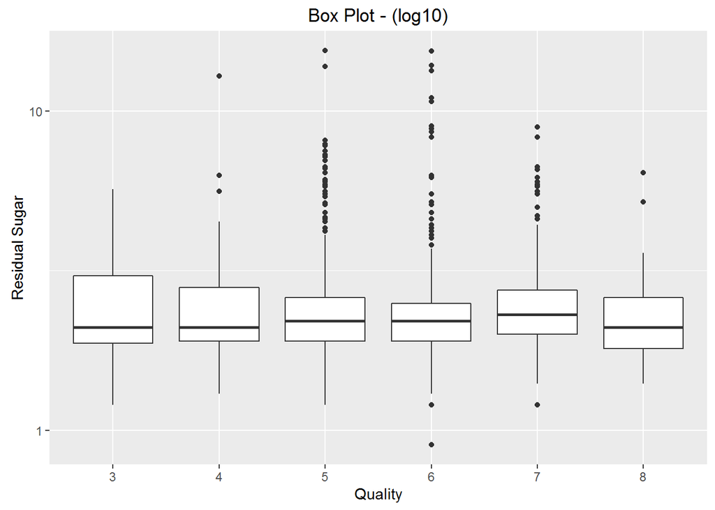

```
##
## Calls:
## m1: lm(formula = quality ~ residual.sugar, data = redWine)
## m2: lm(formula = quality ~ I(sqrt(residual.sugar)), data = redWine)
## m3: lm(formula = quality ~ I(log(residual.sugar)), data = redWine)
##
## ============================================================
##                               m1         m2         m3
## ------------------------------------------------------------
##   (Intercept)               5.616***   5.565***   5.591***
##                            (0.042)    (0.096)    (0.052)
##   residual.sugar            0.008
##                            (0.014)
##   I(sqrt(residual.sugar))              0.046
##                                       (0.060)
##   I(log(residual.sugar))                          0.053
##                                                  (0.057)
## ------------------------------------------------------------
##   R-squared                     0.0        0.0        0.0
##   adj. R-squared               -0.0       -0.0       -0.0
##   sigma                         0.8        0.8        0.8
##   F                             0.3        0.6        0.9
##   p                             0.6        0.4        0.3
##   Log-likelihood            -1926.5    -1926.3    -1926.2
##   Deviance                   1042.0     1041.8     1041.6
##   AIC                        3859.0     3858.7     3858.4
##   BIC                        3875.1     3874.8     3874.5
##   N                          1599       1599       1599
## ============================================================
```

The smallest deviance was obtained through the log base 10 transformation of the Chlorides variable (sodium chloride - g / dm^3). From the box plot we can see a few significant outliers especially near the bottom of the quality 7 bin.

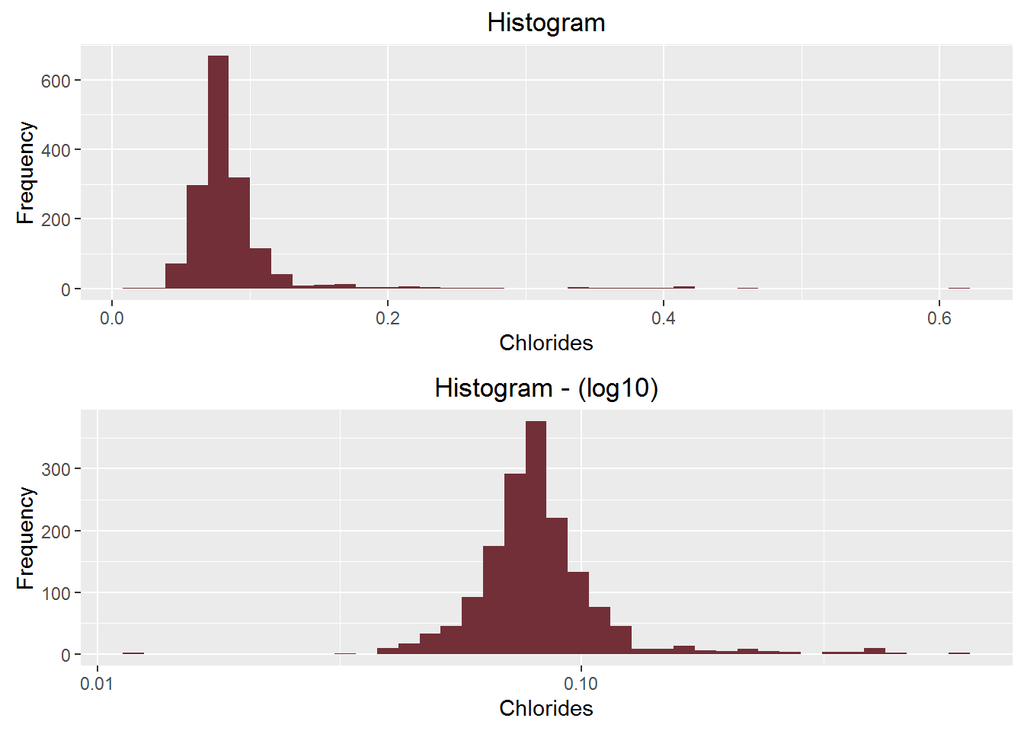

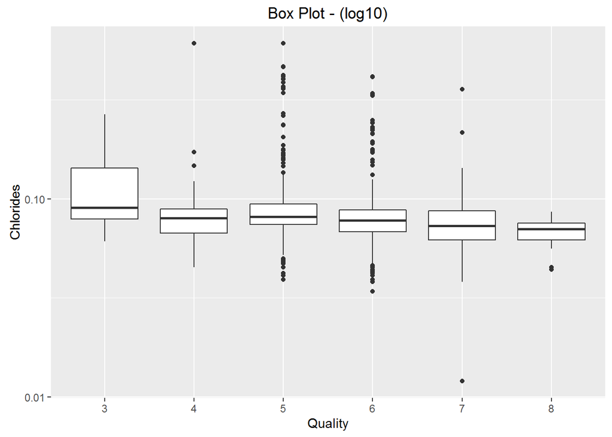

```
##
## Calls:
## m1: lm(formula = quality ~ chlorides, data = redWine)
## m2: lm(formula = quality ~ I(sqrt(chlorides)), data = redWine)
## m3: lm(formula = quality ~ I(log(chlorides)), data = redWine)
##
## =======================================================
##                          m1         m2         m3
## -------------------------------------------------------
##   (Intercept)          5.829***   6.258***   4.547***
##                       (0.042)    (0.102)    (0.154)
##   chlorides           -2.212***
##                       (0.426)
##   I(sqrt(chlorides))             -2.144***
##                                  (0.345)
##   I(log(chlorides))                         -0.435***
##                                             (0.061)
## -------------------------------------------------------
##   R-squared                0.0        0.0        0.0
##   adj. R-squared           0.0        0.0        0.0
##   sigma                    0.8        0.8        0.8
##   F                       27.0       38.6       51.1
##   p                        0.0        0.0        0.0
##   Log-likelihood       -1913.2    -1907.5    -1901.4
##   Deviance              1024.8     1017.5     1009.8
##   AIC                   3832.5     3821.0     3808.9
##   BIC                   3848.6     3837.2     3825.0
##   N                     1599       1599       1599
## =======================================================
```

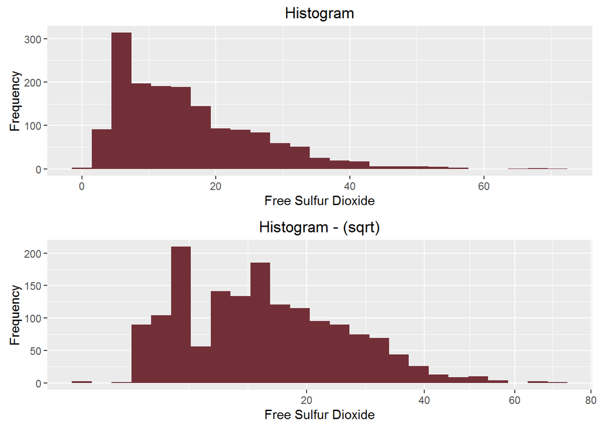

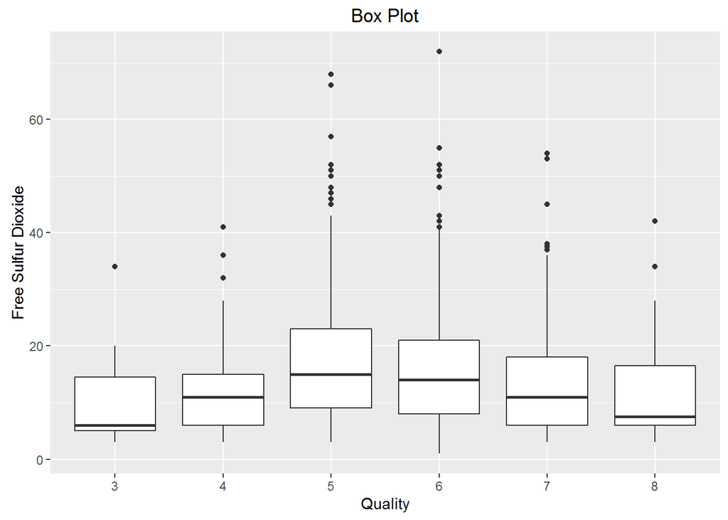

```
##
## Calls:
## m1: lm(formula = quality ~ free.sulfur.dioxide, data = redWine)
## m2: lm(formula = quality ~ I(sqrt(free.sulfur.dioxide)), data = redWine)
## m3: lm(formula = quality ~ I(log(free.sulfur.dioxide)), data = redWine)
##
## =================================================================
##                                    m1         m2         m3
## -----------------------------------------------------------------
##   (Intercept)                    5.698***   5.761***   5.786***
##                                 (0.037)    (0.064)    (0.078)
##   free.sulfur.dioxide           -0.004*
##                                 (0.002)
##   I(sqrt(free.sulfur.dioxide))             -0.033*
##                                            (0.016)
##   I(log(free.sulfur.dioxide))                         -0.059*
##                                                       (0.029)
## -----------------------------------------------------------------
##   R-squared                          0.0        0.0        0.0
##   adj. R-squared                     0.0        0.0        0.0
##   sigma                              0.8        0.8        0.8
##   F                                  4.1        4.2        4.0
##   p                                  0.0        0.0        0.0
##   Log-likelihood                 -1924.6    -1924.5    -1924.6
##   Deviance                        1039.5     1039.4     1039.6
##   AIC                             3855.2     3855.0     3855.3
##   BIC                             3871.3     3871.2     3871.4
##   N                               1599       1599       1599
## =================================================================
```

```
##
## Call:
## lm(formula = quality ~ free.sulfur.dioxide, data = redWine)
##
## Residuals:
##     Min      1Q  Median      3Q     Max
## -2.6864 -0.6394  0.3215  0.3762  2.4661
##
## Coefficients:
##                      Estimate Std. Error t value Pr(>|t|)
## (Intercept)          5.698107   0.036678 155.357   <2e-16 ***
## free.sulfur.dioxide -0.003911   0.001929  -2.027   0.0428 *
## ---
## Signif. codes:  0 '***' 0.001 '**' 0.01 '*' 0.05 '.' 0.1 ' ' 1
##
## Residual standard error: 0.8068 on 1597 degrees of freedom
## Multiple R-squared:  0.002566,   Adjusted R-squared:  0.001941
## F-statistic: 4.109 on 1 and 1597 DF,  p-value: 0.04283
```

The log transformation of Total Sulfur Dioxide (mg / dm^3) has a very normal distribution and is only marginally higher in terms of deviance from the linear regression model. A second version of each model was made using a data set which excludes two significant outliers (‘.2’). As comparison, I have also plotted a box plot of total sulfur dioxide not separated by quality. From this type of plot we can see the significant outliers that should likely be removed from the data set.

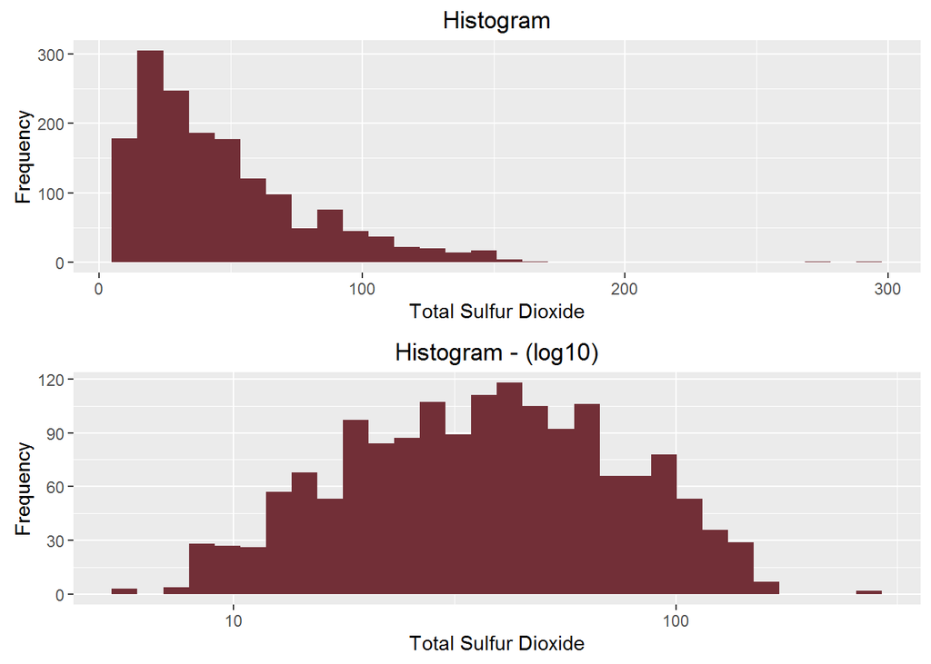

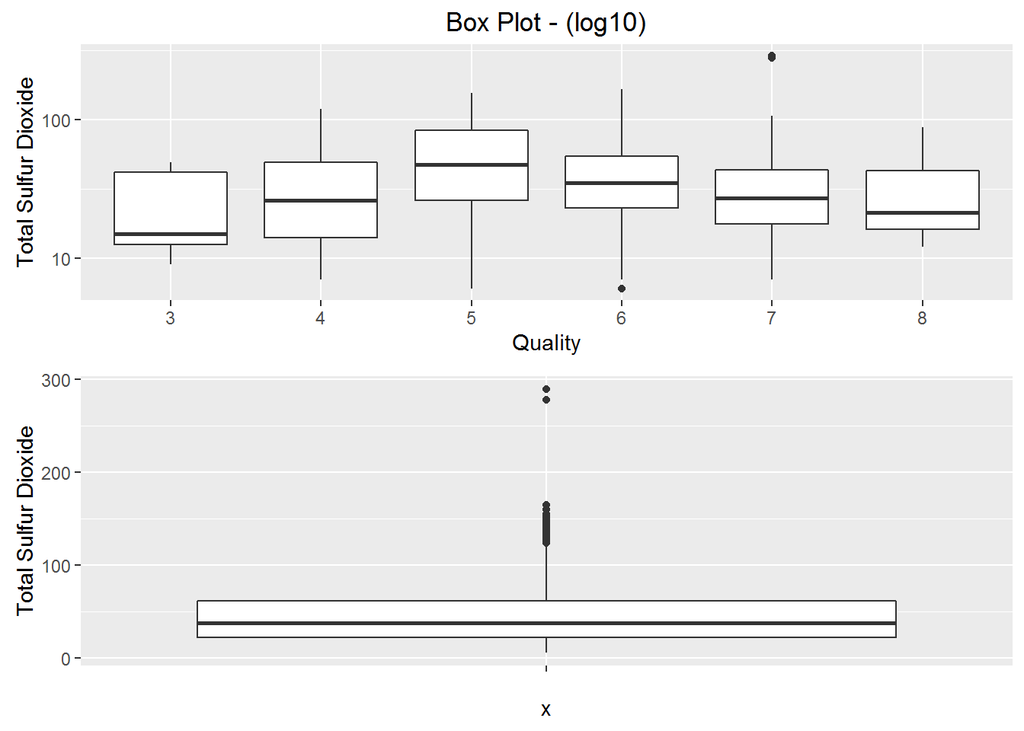

```
##
## Calls:
## m1: lm(formula = quality ~ total.sulfur.dioxide, data = redWine)
## m1.2: lm(formula = quality ~ total.sulfur.dioxide, data = filter(redWine,
##     total.sulfur.dioxide < 250))
## m2: lm(formula = quality ~ I(sqrt(total.sulfur.dioxide)), data = redWine)
## m2.2: lm(formula = quality ~ I(sqrt(total.sulfur.dioxide)), data = filter(redWine,
##     total.sulfur.dioxide < 250))
## m3: lm(formula = quality ~ I(log(total.sulfur.dioxide)), data = redWine)
## m3.2: lm(formula = quality ~ I(log(total.sulfur.dioxide)), data = filter(redWine,
##     total.sulfur.dioxide < 250))
##
## ===================================================================================================
##                                     m1        m1.2        m2        m2.2        m3        m3.2
## ---------------------------------------------------------------------------------------------------
##   (Intercept)                     5.847***   5.877***   6.061***   6.093***   6.337***   6.368***
##                                  (0.034)    (0.035)    (0.060)    (0.060)    (0.104)    (0.104)
##   total.sulfur.dioxide           -0.005***  -0.005***
##                                  (0.001)    (0.001)
##   I(sqrt(total.sulfur.dioxide))                        -0.066***  -0.071***
##                                                        (0.009)    (0.009)
##   I(log(total.sulfur.dioxide))                                               -0.195***  -0.204***
##                                                                              (0.028)    (0.028)
## ---------------------------------------------------------------------------------------------------
##   R-squared                           0.0        0.0        0.0        0.0        0.0        0.0
##   adj. R-squared                      0.0        0.0        0.0        0.0        0.0        0.0
##   sigma                               0.8        0.8        0.8        0.8        0.8        0.8
##   F                                  56.7       71.8       56.1       64.4       47.6       51.9
##   p                                   0.0        0.0        0.0        0.0        0.0        0.0
##   Log-likelihood                  -1898.8    -1887.2    -1899.0    -1890.8    -1903.1    -1896.8
##   Deviance                         1006.5      993.7     1006.8      998.2     1012.0     1005.7
##   AIC                              3803.5     3780.4     3804.1     3787.5     3812.3     3799.6
##   BIC                              3819.7     3796.5     3820.2     3803.7     3828.4     3815.7
##   N                                1599       1597       1599       1597       1599       1597
## ===================================================================================================
```

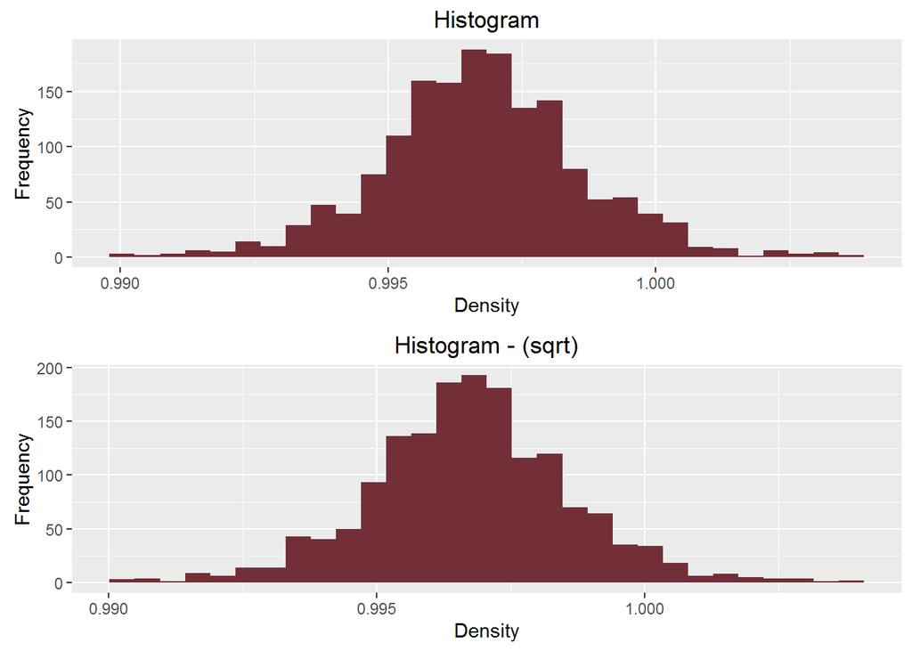

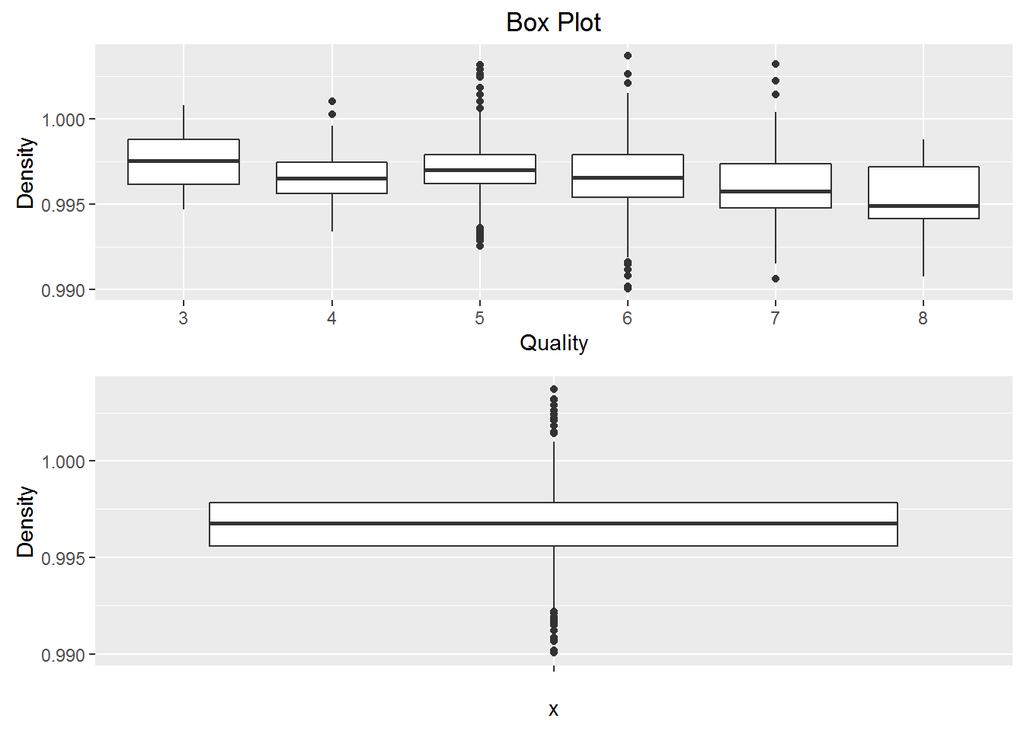

```
##
## Calls:
## m1: lm(formula = quality ~ density, data = redWine)
## m2: lm(formula = quality ~ I(sqrt(density)), data = redWine)
## m3: lm(formula = quality ~ I(log(density)), data = redWine)
##
## =========================================================
##                         m1          m2           m3
## ---------------------------------------------------------
##   (Intercept)        80.239***   154.954***    5.392***
##                     (10.508)     (21.016)     (0.040)
##   density           -74.846***
##                     (10.542)
##   I(sqrt(density))              -149.562***
##                                  (21.050)
##   I(log(density))                            -74.716***
##                                              (10.508)
## ---------------------------------------------------------
##   R-squared              0.0          0.0         0.0
##   adj. R-squared         0.0          0.0         0.0
##   sigma                  0.8          0.8         0.8
##   F                     50.4         50.5        50.6
##   p                      0.0          0.0         0.0
##   Log-likelihood     -1901.8      -1901.8     -1901.7
##   Deviance            1010.3       1010.2      1010.2
##   AIC                 3809.6       3809.5      3809.4
##   BIC                 3825.7       3825.6      3825.6
##   N                   1599         1599        1599
## =========================================================
```

The pH variable shows a fairly normal distribution with only marginal significance for coefficient values in the linear model.

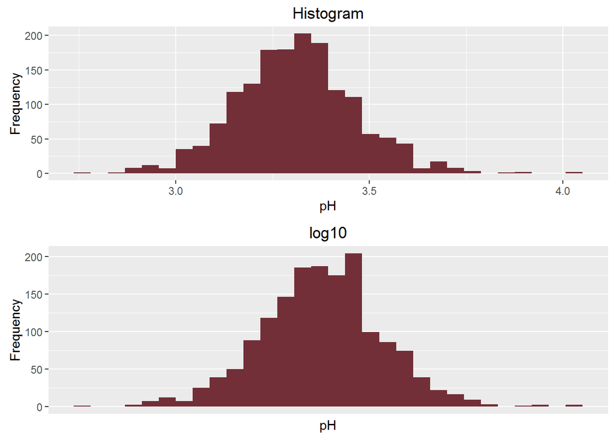

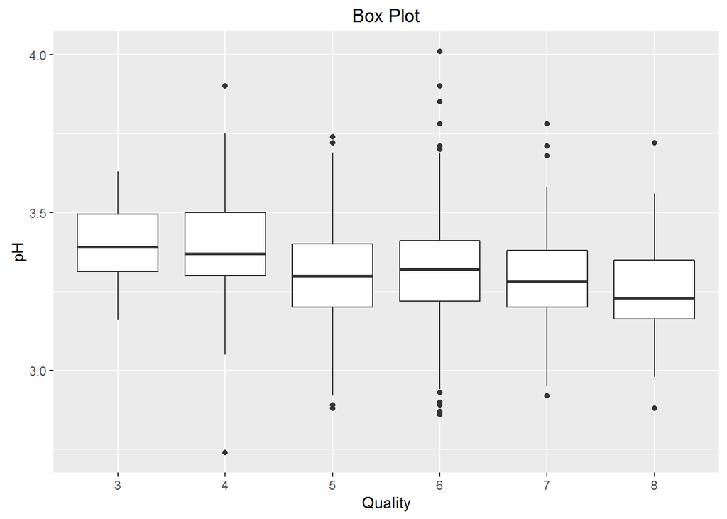

```
##
## Calls:
## m1: lm(formula = quality ~ pH, data = redWine)
## m2: lm(formula = quality ~ I(sqrt(pH)), data = redWine)
## m3: lm(formula = quality ~ I(log(pH)), data = redWine)
##
## ===================================================
##                      m1         m2         m3
## ---------------------------------------------------
##   (Intercept)      6.636***   7.636***   6.830***
##                   (0.433)    (0.866)    (0.519)
##   pH              -0.302*
##                   (0.131)
##   I(sqrt(pH))                -1.099*
##                              (0.476)
##   I(log(pH))                            -0.998*
##                                         (0.433)
## ---------------------------------------------------
##   R-squared            0.0        0.0        0.0
##   adj. R-squared       0.0        0.0        0.0
##   sigma                0.8        0.8        0.8
##   F                    5.3        5.3        5.3
##   p                    0.0        0.0        0.0
##   Log-likelihood   -1924.0    -1924.0    -1924.0
##   Deviance          1038.7     1038.7     1038.7
##   AIC               3853.9     3853.9     3854.0
##   BIC               3870.1     3870.1     3870.1
##   N                 1599       1599       1599
## ===================================================
```

The Sulfates variable (potassium sulfate - g / dm3) show’s high significance in the linear regression model with the lowest deviance being produced by the log transformation of this variable.

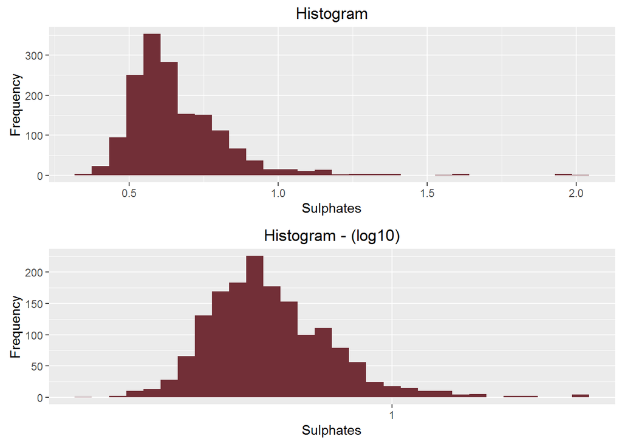

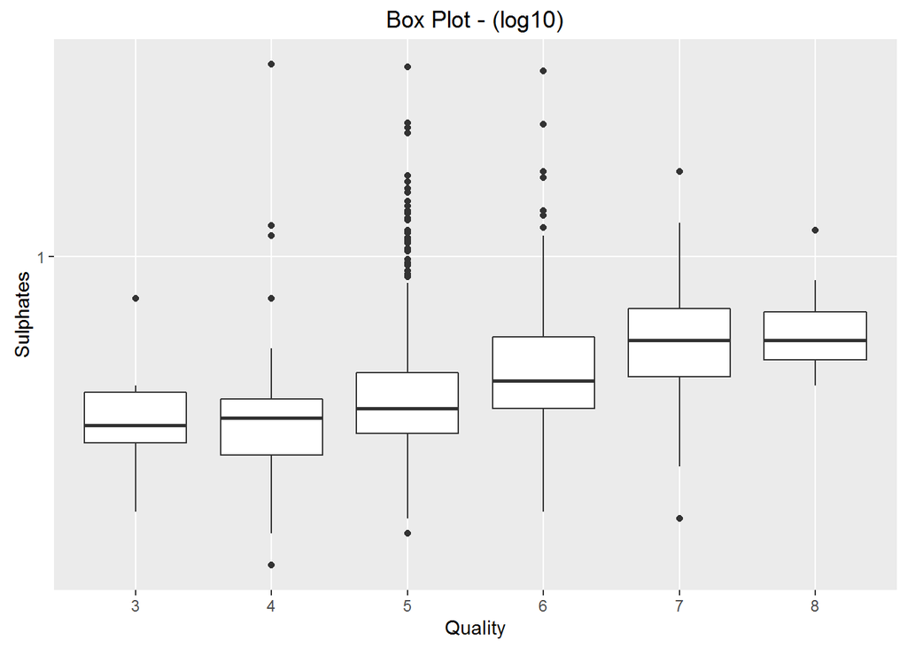

```
##
## Calls:
## m1: lm(formula = quality ~ sulphates, data = redWine)
## m2: lm(formula = quality ~ I(sqrt(sulphates)), data = redWine)
## m3: lm(formula = quality ~ I(log(sulphates)), data = redWine)
##
## =======================================================
##                          m1         m2         m3
## -------------------------------------------------------
##   (Intercept)          4.848***   3.709***   6.132***
##                       (0.078)    (0.164)    (0.043)
##   sulphates            1.198***
##                       (0.115)
##   I(sqrt(sulphates))              2.392***
##                                  (0.203)
##   I(log(sulphates))                          1.115***
##                                             (0.086)
## -------------------------------------------------------
##   R-squared                0.1        0.1        0.1
##   adj. R-squared           0.1        0.1        0.1
##   sigma                    0.8        0.8        0.8
##   F                      107.7      139.4      168.1
##   p                        0.0        0.0        0.0
##   Log-likelihood       -1874.4    -1859.7    -1846.6
##   Deviance               976.3      958.5      942.9
##   AIC                   3754.9     3725.4     3699.2
##   BIC                   3771.0     3741.6     3715.3
##   N                     1599       1599       1599
## =======================================================
```

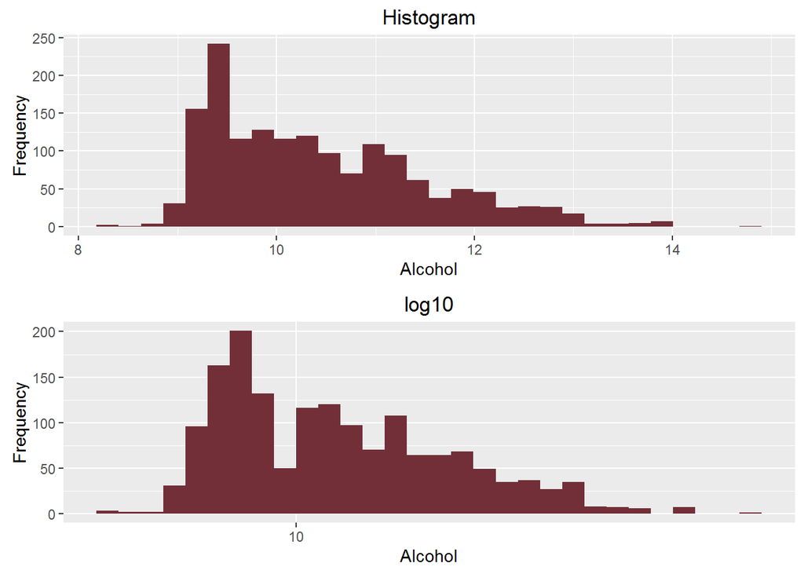

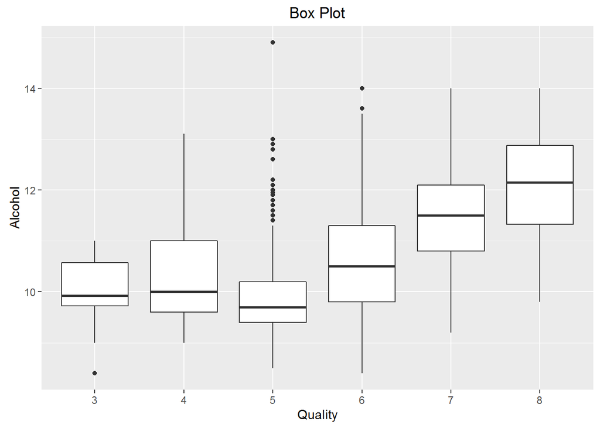

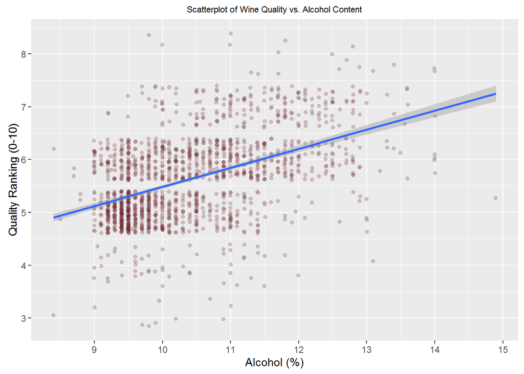

```
##
## Calls:
## m1: lm(formula = quality ~ alcohol, data = redWine)
## m2: lm(formula = quality ~ I(sqrt(alcohol)), data = redWine)
## m3: lm(formula = quality ~ I(log(alcohol)), data = redWine)
##
## =====================================================
##                        m1         m2         m3
## -----------------------------------------------------
##   (Intercept)        1.875***  -2.024***  -3.474***
##                     (0.175)    (0.354)    (0.420)
##   alcohol            0.361***
##                     (0.017)
##   I(sqrt(alcohol))              2.376***
##                                (0.110)
##   I(log(alcohol))                          3.895***
##                                           (0.180)
## -----------------------------------------------------
##   R-squared              0.2        0.2        0.2
##   adj. R-squared         0.2        0.2        0.2
##   sigma                  0.7        0.7        0.7
##   F                    468.3      469.9      470.3
##   p                      0.0        0.0        0.0
##   Log-likelihood     -1721.1    -1720.4    -1720.3
##   Deviance             805.9      805.2      805.1
##   AIC                 3448.1     3446.8     3446.5
##   BIC                 3464.2     3463.0     3462.6
##   N                   1599       1599       1599
## =====================================================
```

## Uni/bivariate Analysis

### Structure of the dataset

Wine quality is scored as an integer between 0 and 10. The predictor variables are as follows:

**Fixed Acidity** (tartaric acid - g / dm^3)

**Volatile Acidity** (acetic acid - g / dm^3)

**Citric Acid** (g / dm^3)

**Residual Sugar** (g / dm^3)

**Chlorides** (sodium chloride - g / dm^3)

**Free Sulfur Dioxide** (mg / dm^3)

**Total Sulfur Dioxide** (mg / dm^3)

**Density** (g / cm^3)

**pH**

**Sulphates** (potassium sulfate - g / dm3)

**Alcohol** (% by volume)

### Main features of interest in the dataset

From analyzing the predictor variables in the linear models, we can see that most variables do have at least some statistical significance in terms of estimated linear coefficients with the exception of residual sugar. Although due to the nature of wine, or food and drinks in general, I believe that a good quality wine would be a function of a certain balance between these variables as well as the combined affect of some of these variables together.

### New variables in the dataset

The only new variable that was added to the data set was a factored version of quality so that certain analysis such as the box plots. In the case of this data set, the qualities were all in the form of integers so there was no modification needed to be made in order to round number up or down.

### Variable transformation

All of the variables have been put through a square root transformation as well as a log base 10 transformation in order to observe the affect these transformations would have on both the distributions as well as the linear model accuracy.

## Multivariate Plots Section

The following plot matrix looks analyses how each variable interacts with each other as well as their relationship with quality via the colour of the point. After analyzing the first plot, it was difficult to observe any potential clustering of qualities. The colour code was then changed such that only wines rated 7 or 8 would show up as red. Sorting the data set by quality made it so that the (fewer) quality 7 and 8 wines, represented by red circles, would show up on top of the black circles, which make up the majority of red wines (qualities 3-6). It is difficult to see each individual panel of the matrix in the html output so a re-created version of these pairs was made with some of the variables omitted. Further analysis on multiple variables will be explored based on these plots. *Note the quality axis labeling is offset by 2 (1->3, 6->8).

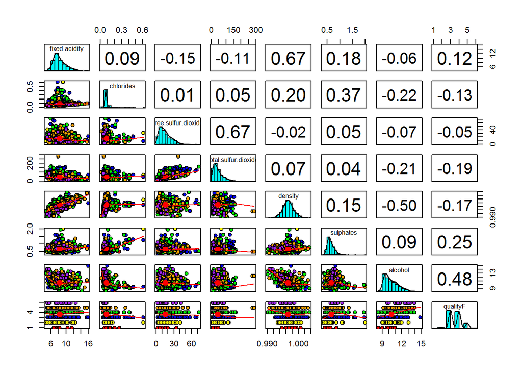

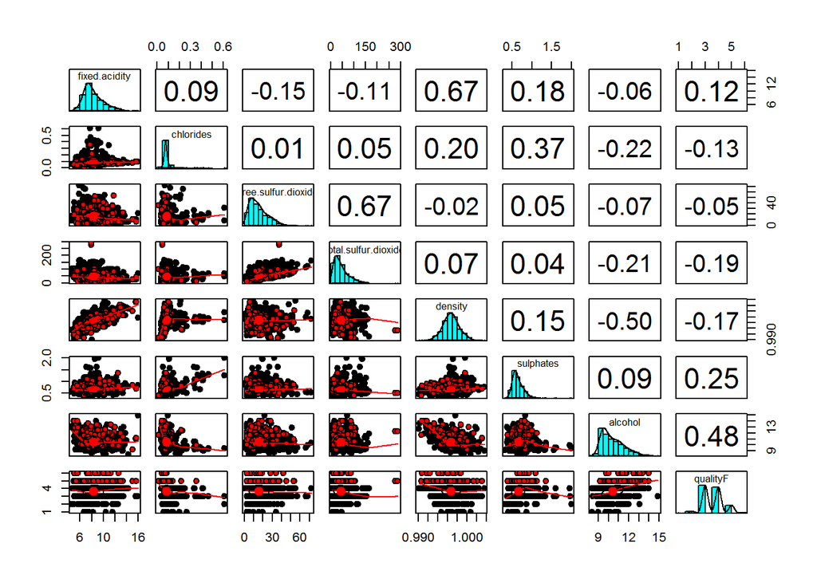

Below are a few multivariate plots that take two predictor variables, as the x and y-axis, and represent quality via the size and colour of the points. The size adjustments were used in addition to the colour adjustment because it would allow us to better visualize the higher quality wines. QualityF and Quality-2 are slight manipulations of the quality variable. QualityF is the factored form of quality and Quality-2 allow the points on the graph to scale from 1 to 6.

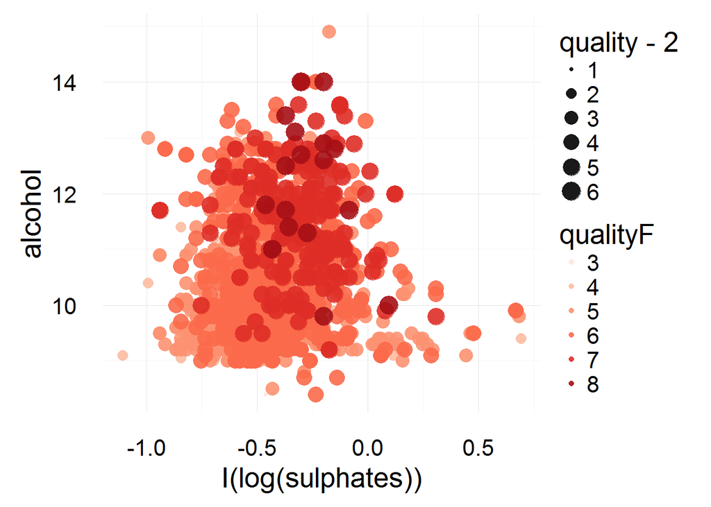

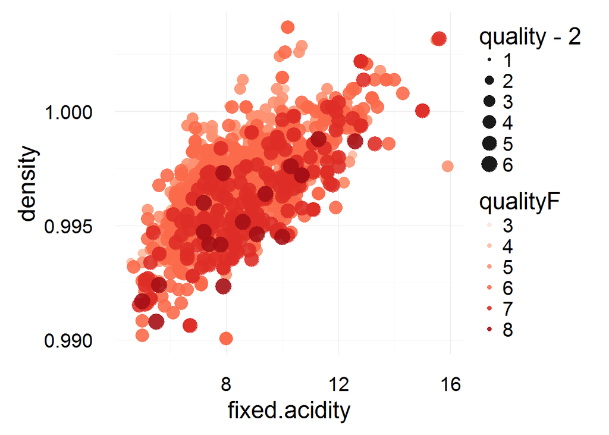

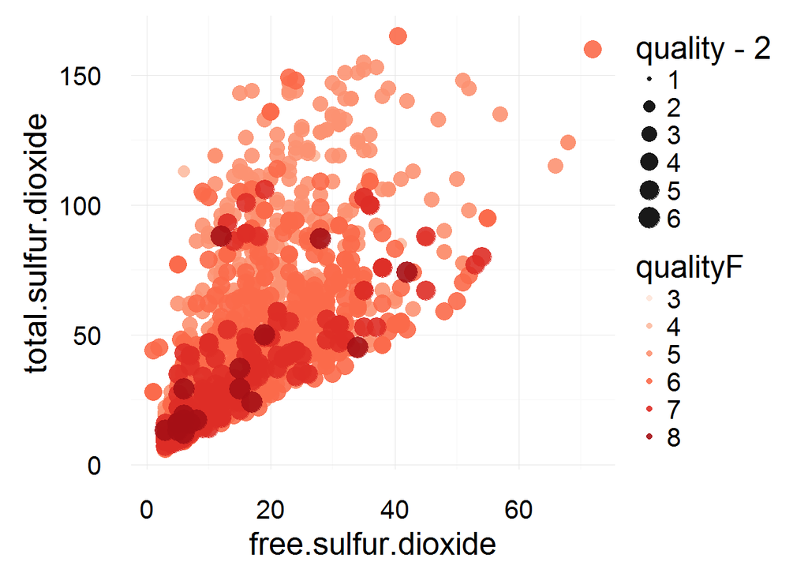

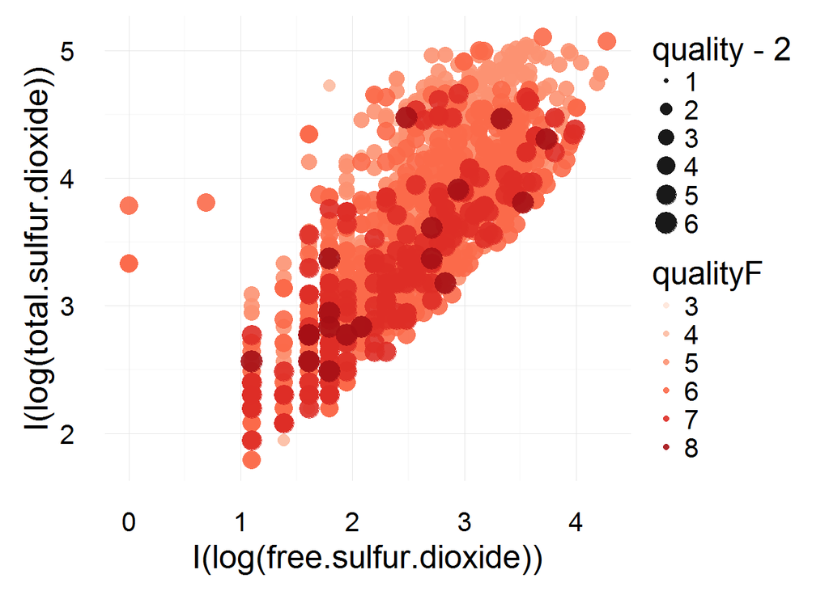

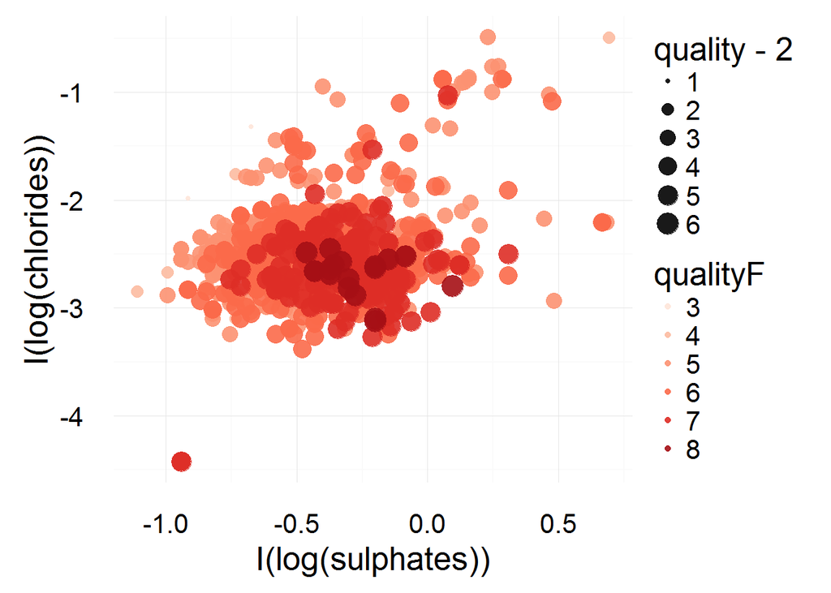

It is difficult to tell from simply observing the graphs above whether two predictors actually have significant interaction or if both variables are simply positively correlated with the output variable. To determine which variables have significant interference with each other we would have to test each variable against each other and look at each of the 55 (11 choose 2) corresponding p values. Although we could do this in practice, it is beyond the scope of this project.

## Building a Model

According to the textbook “**An Introduction to Statistical Learning** with Applications in R” by *Garath James, Daniela Witten, Trevor Hastie,* and *Robert Tibshirani* the best way to select variables for a linear model is to use a method called *‘Mixed Selection’* which is a combination of forward and backward selection. This method works as follows:

*“We start with no variables in the model, and as with forward selection, we add the variable that provides the best fit. We continue to add variables one-by-one. The p-values for variables can become larger as the new predictors are added to the model. Hence, if at any point the p-value for one of the variables in the model rises above a certain threshold, then we remove that variable from the model. We continue to perform these forward and backward steps until all the variables in the model have a sufficiently low p-value, and all the variables outside the model would have a large p-value if added to the model”*

The following output demonstrates the end result of iterating through the variables until none of the remaining variables had statistical significance.

```
##
## Calls:
## m1: lm(formula = quality ~ alcohol + I(sqrt(volatile.acidity)) +
##     I(log(chlorides)) + I(log(sulphates)) + I(log(f.s.d.)) +
##     I(log(t.s.d.)) + pH + I(log(chlorides)):I(log(sulphates)) +
##     I(log(f.s.d.)):I(log(t.s.d.)), data = redWine2)
## m2: lm(formula = quality ~ alcohol + I(sqrt(volatile.acidity)) +
##     I(log(chlorides)) + I(log(sulphates)) + I(log(f.s.d.)) +
##     I(log(t.s.d.)) + pH + fixed.acidity + I(log(chlorides)):I(log(sulphates)) +
##     I(log(f.s.d.)):I(log(t.s.d.)), data = redWine2)
## m3: lm(formula = quality ~ alcohol + I(sqrt(volatile.acidity)) +
##     I(log(chlorides)) + I(log(sulphates)) + I(log(f.s.d.)) +
##     I(log(t.s.d.)) + pH + citric.acid + I(log(chlorides)):I(log(sulphates)) +
##     I(log(f.s.d.)):I(log(t.s.d.)), data = redWine2)
## m4: lm(formula = quality ~ alcohol + I(sqrt(volatile.acidity)) +
##     I(log(chlorides)) + I(log(sulphates)) + I(log(f.s.d.)) +
##     I(log(t.s.d.)) + pH + residual.sugar + I(log(chlorides)):I(log(sulphates)) +
##     I(log(f.s.d.)):I(log(t.s.d.)), data = redWine2)
## m5: lm(formula = quality ~ alcohol + I(sqrt(volatile.acidity)) +
##     I(log(chlorides)) + I(log(sulphates)) + I(log(f.s.d.)) +
##     I(log(t.s.d.)) + pH + density + I(log(chlorides)):I(log(sulphates)) +
##     I(log(f.s.d.)):I(log(t.s.d.)), data = redWine2)
##
## =================================================================================================
##                                             m1         m2         m3         m4          m5
## -------------------------------------------------------------------------------------------------
##   (Intercept)                             4.146***   4.377***   4.573***   4.100***   13.413
##                                          (0.463)    (0.643)    (0.558)    (0.469)    (11.214)
##   alcohol                                 0.284***   0.284***   0.289***   0.283***    0.277***
##                                          (0.017)    (0.017)    (0.018)    (0.017)     (0.019)
##   I(sqrt(volatile.acidity))              -1.253***  -1.259***  -1.370***  -1.257***   -1.248***
##                                          (0.148)    (0.149)    (0.170)    (0.148)     (0.148)
##   I(log(chlorides))                      -0.356***  -0.361***  -0.344***  -0.357***   -0.359***
##                                          (0.070)    (0.070)    (0.070)    (0.070)     (0.070)
##   I(log(sulphates))                      -0.671     -0.705     -0.656     -0.645      -0.741
##                                          (0.392)    (0.398)    (0.392)    (0.394)     (0.401)
##   I(log(f.s.d.))                          0.670***   0.670***   0.645***   0.682***    0.665***
##                                          (0.129)    (0.129)    (0.130)    (0.130)     (0.129)
##   I(log(t.s.d.))                          0.181*     0.181*     0.180*     0.187*      0.183*
##                                          (0.091)    (0.092)    (0.091)    (0.092)     (0.092)
```

[output cut: 11 more lines]

```
##                                                                           (0.012)
##   density                                                                             -9.147
##                                                                                      (11.059)
## -------------------------------------------------------------------------------------------------
##   R-squared                                   0.4        0.4        0.4        0.4        0.4
##   adj. R-squared                              0.4        0.4        0.4        0.4        0.4
##   sigma                                       0.6        0.6        0.6        0.6        0.6
##   F                                         108.2       97.3       97.6       97.4       97.4
##   p                                           0.0        0.0        0.0        0.0        0.0
##   Log-likelihood                          -1519.4    -1519.2    -1518.4    -1519.2    -1519.0
##   Deviance                                  631.6      631.5      630.8      631.4      631.3
##   AIC                                      3060.8     3062.5     3060.9     3062.3     3062.1
##   BIC                                      3119.8     3126.9     3125.3     3126.7     3126.5
##   N                                        1584       1584       1584       1584       1584
## =================================================================================================
```

```
##
## Call:
## lm(formula = quality ~ alcohol + I(sqrt(volatile.acidity)) +
##     I(log(chlorides)) + I(log(sulphates)) + I(log(f.s.d.)) +
##     I(log(t.s.d.)) + pH + I(log(chlorides)):I(log(sulphates)) +
##     I(log(f.s.d.)):I(log(t.s.d.)), data = redWine2)
##
## Residuals:
##      Min       1Q   Median       3Q      Max
## -2.70428 -0.35634 -0.04136  0.42602  1.91425
##
## Coefficients:
##                                     Estimate Std. Error t value Pr(>|t|)
## (Intercept)                          4.14575    0.46328   8.949  < 2e-16
## alcohol                              0.28398    0.01724  16.471  < 2e-16
## I(sqrt(volatile.acidity))           -1.25339    0.14808  -8.464  < 2e-16
## I(log(chlorides))                   -0.35603    0.06983  -5.098 3.84e-07
## I(log(sulphates))                   -0.67051    0.39221  -1.710  0.08754
## I(log(f.s.d.))                       0.66968    0.12871   5.203 2.22e-07
## I(log(t.s.d.))                       0.18138    0.09148   1.983  0.04758
## pH                                  -0.59744    0.11737  -5.090 4.00e-07
## I(log(chlorides)):I(log(sulphates)) -0.60908    0.15875  -3.837  0.00013
## I(log(f.s.d.)):I(log(t.s.d.))       -0.15216    0.03444  -4.418 1.06e-05
##
## (Intercept)                         ***
## alcohol                             ***
## I(sqrt(volatile.acidity))           ***
## I(log(chlorides))                   ***
## I(log(sulphates))                   .
## I(log(f.s.d.))                      ***
## I(log(t.s.d.))                      *
## pH                                  ***
## I(log(chlorides)):I(log(sulphates)) ***
## I(log(f.s.d.)):I(log(t.s.d.))       ***
## ---
## Signif. codes:  0 '***' 0.001 '**' 0.01 '*' 0.05 '.' 0.1 ' ' 1
##
## Residual standard error: 0.6335 on 1574 degrees of freedom
## Multiple R-squared:  0.3822, Adjusted R-squared:  0.3786
## F-statistic: 108.2 on 9 and 1574 DF,  p-value: < 2.2e-16
```

*Before removing outliers:* R^2 = 0.3588